# AnkeXu_Project1_HappyDB

Anke Xu

2018/9/16

### Step 0 - Load all the required libraries

From the packages’ descriptions:

- `tm` is a framework for text mining applications within R;
- `tidyverse` is an opinionated collection of R packages designed for data science. All packages share an underlying design philosophy, grammar, and data structures;
- `tidytext` allows text mining using ‘dplyr’, ‘ggplot2’, and other tidy tools;
- `DT` provides an R interface to the JavaScript library DataTables.

```r
library(tm)
library(tidytext)
library(tidyverse)
library(DT)
# multiplot()
```

### Step 1 - Load the data to be cleaned and processed

```r
urlfile<-'https://raw.githubusercontent.com/rit-public/HappyDB/master/happydb/data/cleaned_hm.csv'
hm_data <- read_csv(urlfile)
urlfile2<-'https://raw.githubusercontent.com/rit-public/HappyDB/master/happydb/data/demographic.csv'
demo_data <- read_csv(urlfile2)
```

### Step 2 - Preliminary cleaning of text

We clean the text by converting all the letters to the lower case, and removing punctuation, numbers, empty words and extra white space.

```r
corpus <- VCorpus(VectorSource(hm_data$cleaned_hm))%>%
  tm_map(content_transformer(tolower))%>%
  tm_map(removePunctuation)%>%
  tm_map(removeNumbers)%>%
  tm_map(removeWords, character(0))%>%
  tm_map(stripWhitespace)
```

### Step 3 - Stemming words and converting tm object to tidy object

Stemming reduces a word to its word *stem*. We stem the words here and then convert the “tm” object to a “tidy” object for much faster processing.

```r
stemmed <- tm_map(corpus, stemDocument) %>%
  tidy() %>%
  select(text)
```

### Step 4 - Creating tidy format of the dictionary to be used for completing stems

We also need a dictionary to look up the words corresponding to the stems.

```r
dict <- tidy(corpus) %>%
  select(text) %>%
  unnest_tokens(dictionary, text)
```

### Step 5 - Removing stopwords that don’t hold any significant information for our data set

We remove stopwords provided by the “tidytext” package and also add custom stopwords in context of our data.

```r
data("stop_words")
word <- c("happy","ago","yesterday","lot","today","months","month",'weeks','havent','couldnt','theyll','im','happiness','initially',
                 'hadnt',"happier","happiest","last","week","past",'day','time','moment','im','finally','days','nice','recently','favorite')
stop_words <- stop_words %>%
  bind_rows(mutate(tibble(word), lexicon = "updated"))
```

### Step 6 - Combining stems and dictionary into the same tibble

Here we combine the stems and the dictionary into the same “tidy” object.

```r
completed <- stemmed %>%
  mutate(id = row_number()) %>%
  unnest_tokens(stems, text) %>%
  bind_cols(dict) %>%
  anti_join(stop_words, by = c("dictionary" = "word"))
```

### Step 7 - Stem completion

Lastly, we complete the stems by picking the corresponding word with the highest frequency.

```r
completed <- completed %>%
  group_by(stems) %>%
  count(dictionary) %>%
  mutate(word = dictionary[which.max(n)]) %>%
  ungroup() %>%
  select(stems, word) %>%
  distinct() %>%
  right_join(completed) %>%
  select(-stems)
```

### Step 8 - Pasting stem completed individual words into their respective happy moments

We want our processed words to resemble the structure of the original happy moments. So we paste the words together to form happy moments.

```r
completed <- completed %>%
  group_by(id) %>%
  summarise(text = str_c(word, collapse = " ")) %>%
  ungroup()
```

### Step 9 - Keeping a track of the happy moments with their own ID

```r
hm_data <- hm_data %>%
  mutate(id = row_number()) %>%
  inner_join(completed)
```

### Step 10 - Combine both the data sets and keep the required columns for analysis

We select a subset of the data that satisfies specific row conditions.

```r
library(wordcloud2)
library(wordcloud)
library(ngram)
library(RColorBrewer)
library(plotly)
library(dplyr)
library(Rmisc)
library(ggplot2)
library(reshape)
library(gridExtra)
hm_data <- hm_data %>%
  inner_join(demo_data, by = "wid") %>%
  select(wid,
         original_hm,
         cleaned_hm,
         gender,
         marital,
         parenthood,
         reflection_period,
         age,
         country,
         ground_truth_category,
         text) %>%
  mutate(count = sapply(hm_data$text, wordcount)) %>%
  filter(gender %in% c("m", "f")) %>%
  filter(marital %in% c("single", "married")) %>%
  filter(parenthood %in% c("n", "y")) %>%
  filter(reflection_period %in% c("24h", "3m")) %>%
  mutate(reflection_period = fct_recode(reflection_period,
                                        months_3 = "3m", hours_24 = "24h"))
```

### Step 11 - Data cleaning

We are going to see what the description of the data and then clean the data by examining the features of country, gender, age, marital status, parenthood. We found the missing data in country, age and ground_truth_category.

```r
sort(sapply(hm_data,function(x){sum(is.na(x))}),decreasing = TRUE)
```

```
ground_truth_category               country                   age                   wid           original_hm
                81116                   147                    33                     0                     0
           cleaned_hm                gender               marital            parenthood     reflection_period
                    0                     0                     0                     0                     0
                 text                 count
                    0                     0
```

Since country and age are the two topics we’re interested in, we omit the data points that are not having those information for our analysis.

```r
hm_data <- hm_data[!is.na(hm_data$country),] # Omit the data points that are not having country information
hm_data <- hm_data[!is.na(hm_data$age),]     # Omit the data points that are not having age information
```

### Step 12 - Creating the word cloud and bar graph to acquire top 100 keywords

We would like to create a word cloud graph to explore what really makes staff happy.

```r
wordcount_data <- hm_data$text %>% str_trim() %>% lapply(strsplit," ") %>% unlist() %>% table() %>% as.data.frame()
colnames(wordcount_data) <- c("Keyword","Freq")
sorted_data <- wordcount_data %>% dplyr::arrange(desc(Freq))
wordcloud2(sorted_data[1:100,], size = 0.5,shape = "circle")
```

[interactive chart not shown]

We select the top-20 highest frequence words to explore the significant factors of happiness.

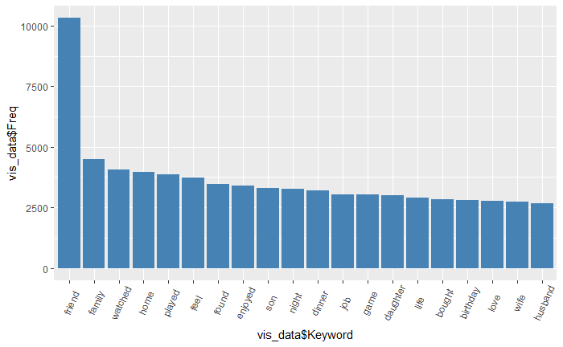

```r
vis_data <- head(sorted_data, n =20)
g <- ggplot(vis_data,aes(fill=vis_data$Keyword)) + geom_bar(aes(x=vis_data$Keyword,y=vis_data$Freq),stat='identity',fill="steelblue")+theme(axis.text.x = element_text(angle=65, vjust=0.6)) +scale_x_discrete(limits= vis_data$Keyword) + guides(fill=FALSE)
g
```

The words are mostly associated with ‘friends’:

```r
hm_data_associate <- hm_data[hm_data$count > 2,]
set.seed(223)
dtm <- DocumentTermMatrix(VCorpus(VectorSource(sample(hm_data_associate$text,200))))
as.matrix(dtm)
```

```r
findAssocs(dtm, terms = "friend", corlimit = 0.2)
```

```
$`friend`
         party       birthday     artificial       attended         awhile babycelebrated       beachits          birth
          0.31           0.26           0.21           0.21           0.21           0.21           0.21           0.21
           bit         boston         cinema      connected        contact          drink      fantastic           golf
          0.21           0.21           0.21           0.21           0.21           0.21           0.21           0.21
          hole          hours         letter           lost       marriage      memorable           park          phone
          0.21           0.21           0.21           0.21           0.21           0.21           0.21           0.21
        pickup    reconnected           ride            sky           snow          sunny          theme         tuxedo
          0.21           0.21           0.21           0.21           0.21           0.21           0.21           0.21
```

### Step13: Topic 1 - What are the different words mentioned by different Countries, USA vs IND? Does it relate to their culture background?

#### the United States and India, two countries, have much more data points than other countries.

```r
count(hm_data$country)[count(hm_data$country)$freq>500,]
```

|  | x | freq |
| --- | --- | --- |
| 15 | CAN | 531 |
| 40 | IND | 16615 |
| 94 | USA | 73377 |
| 95 | VEN | 546 |

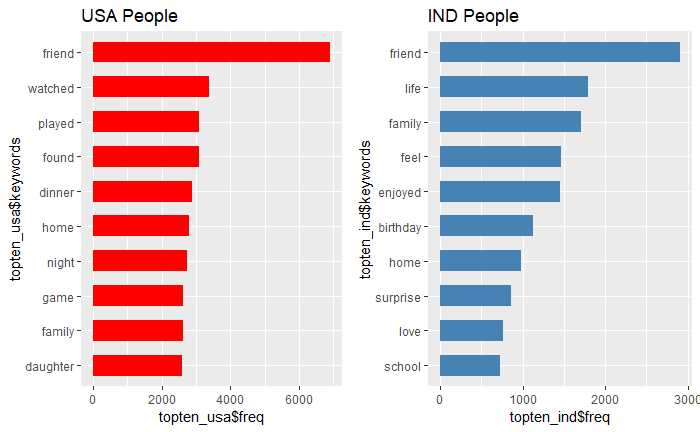

```r
library(gridExtra)
usa_people <- hm_data[which(hm_data$country=="USA"),]
usa_people_word <- usa_people$text %>% str_trim() %>% lapply(strsplit," ") %>% unlist() %>% table() %>% as.data.frame() %>% dplyr::arrange(desc(Freq))
ind_people <- hm_data[which(hm_data$country=="IND"),]
ind_people_word <- ind_people$text %>% str_trim() %>% lapply(strsplit," ") %>% unlist() %>% table() %>% as.data.frame() %>% dplyr::arrange(desc(Freq))
topten_usa<-  usa_people_word[1:10,]
names(topten_usa) <- c("keywords","freq")
g_usa<-ggplot(topten_usa) + geom_bar(aes(x=topten_usa$keywords,y=topten_usa$freq),position="dodge",stat = "identity",width=0.6,fill="red")+scale_x_discrete(limits= rev(topten_usa$keywords))+ guides(fill=F)+ggtitle("USA People")+coord_flip()
topten_ind<- ind_people_word[1:10,]
names(topten_ind) <- c("keywords","freq")
g_ind<-ggplot(topten_ind) + geom_bar(aes(x=topten_ind$keywords,y=topten_ind$freq),position="dodge",stat = "identity",width=0.6,fill="steelblue")+scale_x_discrete(limits= rev(topten_ind$keywords))+ guides(fill=F)+ggtitle("IND People")+coord_flip()
#g_usa,g_ind
grid.arrange(g_usa,g_ind,ncol=2,nrow=1)
```

```r
#cowplot::plot_grid(g_usa,g_ind,labels = "AUTO" )
```

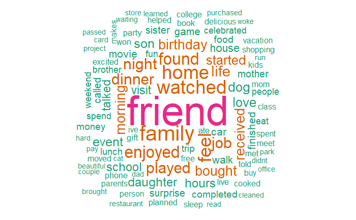

```r
library(RColorBrewer)
commonality.cloud(tdm, random.order=FALSE, scale=c(5, .5),colors = brewer.pal(4, "Dark2"), max.words=100)
```

#### The different words used by these two countries - Comparison Cloud

A comparison cloud compares the relative frequency with which a term was used in two or more groups and it plots the difference between the word usage in the documents.

From the comparison cloud, we can see that words like ‘life’ and ‘family’ were more front-and-center in India than in USA. We also see words like ‘temple’ and ‘purchased’, which didn’t exist (at least by that name) in USA, pop up in India’s word cloud, which means it has been used more by India workers.

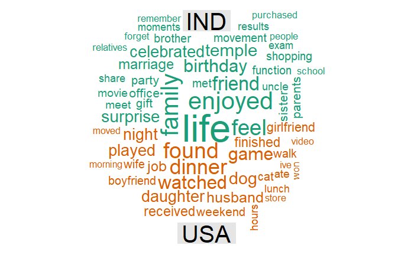

```r
hm_data_country<- hm_data[hm_data$country=='USA'|hm_data$country=='IND',]
bag_of_words2 <-  hm_data_country %>%
  unnest_tokens(word, text)
word_count2 <- bag_of_words2 %>%group_by(country)%>%
  dplyr::count(word, sort = TRUE)
tdm2 <- cast(word_count2,word~country,value = 'n')
tdm2[is.na(tdm2)] <- 0
rownames(tdm2) <- tdm2$word
tdm2$word <- NULL
par(mfrow=c(1,1))
comparison.cloud(tdm2, random.order=FALSE,
                 title.size=2.5, max.words=60)
```

### Step 14: Topic 2 - What are the different words mentioned by different Age groups (Young Adults, Middle Age and Senior) and Gender? And what are the reasons they mentioned some words than other words?

#### Create Age Groups

```r
hm_data$age <- as.numeric(hm_data$age)
hm_data <- hm_data[!is.na(hm_data$age),]
hm_data <- hm_data[hm_data$age<100,] ## Clean the outliers
hm_data <- hm_data[hm_data$age>10,]  ## Clean the outliers
summary(hm_data$age)
```

```
   Min. 1st Qu.  Median    Mean 3rd Qu.    Max.
  17.00   25.00   30.00   31.86   35.00   95.00
```

```r
hm_data$age_group <- ifelse(hm_data$age <= 25,"Young",ifelse(hm_data$age <= 40,"Middle","Senior"))
```

#### Check the distribution of age by gender

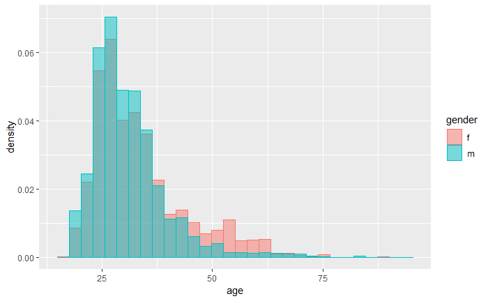

```r
#ggplot(hm_data, aes(x=age)) + geom_histogram()
ggplot(hm_data, aes(x=age, color=gender,fill = gender)) +
  geom_histogram(aes(y=..density..), position="identity", alpha=0.5)
```

#### Check the gender ratio for each age group we created

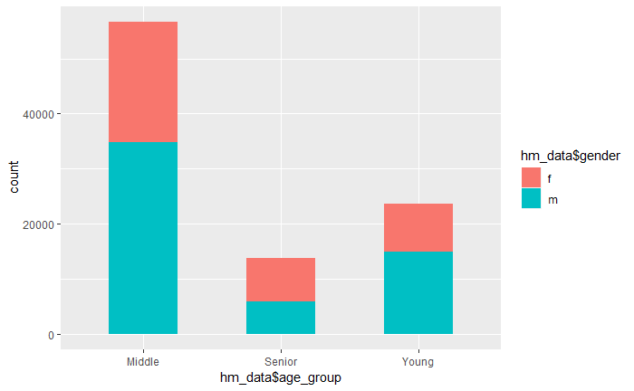

```r
con_data<- hm_data[,c(13)] %>% dplyr::group_by(age_group) %>% count()
con_data <- na.omit(con_data)
#ggplot(con_data,aes(fill=con_data$age_group)) + geom_bar(aes(x= con_data$age_group,y=con_data$freq),stat = 'identity')
g <- ggplot(hm_data,aes(x=hm_data$age_group)) + geom_bar(aes(y = ..count..,fill = hm_data$gender),width = 0.5)
g
```

#### The different words used by these three age groups - Comparison Cloud

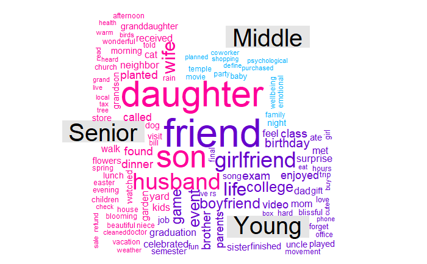

```r
bag_of_words <-  hm_data %>%
  unnest_tokens(word, text)
word_count3 <- bag_of_words %>%group_by(age_group)%>%
  dplyr::count(word, sort = TRUE)
tdm3 <- cast(word_count3,word~age_group,value = 'n')
tdm3[is.na(tdm3)] <- 0
rownames(tdm3) <- tdm3$word
tdm3$word <- NULL
par(mfrow=c(1,1))
comparison.cloud(tdm3, random.order=FALSE,colors = c("#00B2FF", "#FF0099", "#6600CC"),
                 title.size=2.5, max.words=150)
```

From this comparison cloud, we can see that words like ‘friend’, ‘game’ and words related to school were more front-and-center in young adult group than in other two groups. We also see words are smaller in the Middle Age Group, which means this age group shares lots of same words with both two other groups. Words like ‘daughter’ and ‘flowers’ have been used more by senior workers.

#### The different words used by male and female - Comparison Cloud

[figure not shown]

```r
library(reshape)
bag_of_words <-  hm_data %>%
  unnest_tokens(word, text)
word_count <- bag_of_words %>%group_by(gender)%>%
  dplyr::count(word, sort = TRUE)
tdm <- cast(word_count,word~gender,value = 'n')
tdm[is.na(tdm)] <- 0
rownames(tdm) <- tdm$word
tdm$word <- NULL
par(mfrow=c(1,1))
comparison.cloud(tdm, random.order=FALSE, colors = c("indianred3","lightsteelblue3"),
                 title.size=2.5, max.words=200)
```

The gender difference is easy to see by using comparison cloud.

### Step 15: Topic 3 - What are the effect of marriage and parenthood on different age group (Young Adults, Middle Age and Senior)? And what are the reasons they mentioned some words than other words?

#### Age & Marital

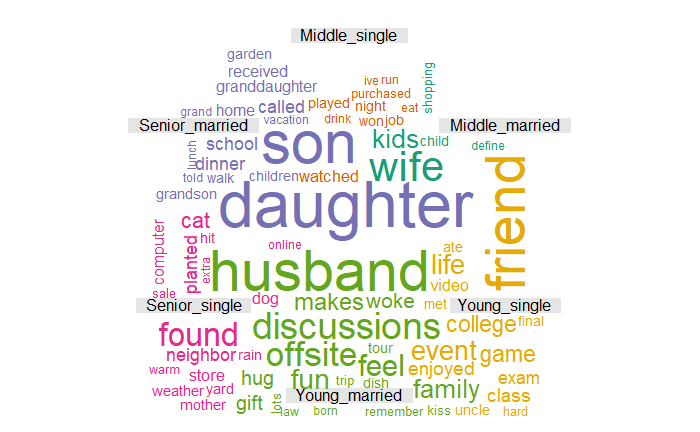

```r
hm_data$combined <- apply( hm_data[ ,c('age_group','marital') ] , 1 , paste , collapse = "_" )
bag_of_words3 <-  hm_data %>%
  unnest_tokens(word, text)
word_count3 <- bag_of_words3 %>%group_by(combined)%>%
  dplyr::count(word, sort = TRUE)
tdm3 <- cast(word_count3,word~combined,value = 'n')
tdm3[is.na(tdm3)] <- 0
rownames(tdm3) <- tdm3$word
tdm3$word <- NULL
par(mfrow=c(1,1))
comparison.cloud(tdm3, random.order=FALSE,
                 title.size=1, max.words=150)
```

```r
NA
```

#### Age & Parenthood

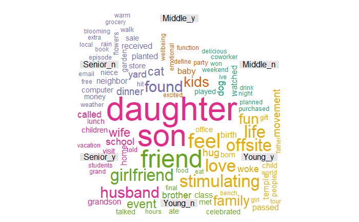

```r
hm_data$combined2 <- apply( hm_data[ ,c('age_group','parenthood') ] , 1 , paste , collapse = "_" )
bag_of_words4 <-  hm_data %>%
  unnest_tokens(word, text)
word_count4 <- bag_of_words4 %>%group_by(combined2)%>%
  dplyr::count(word, sort = TRUE)
tdm4 <- cast(word_count4,word~combined2,value = 'n')
tdm4[is.na(tdm4)] <- 0
rownames(tdm4) <- tdm4$word
tdm4$word <- NULL
par(mfrow=c(1,1))
comparison.cloud(tdm4, random.order=FALSE,
                 title.size=1, max.words=150)
```

```r
NA
```

People engaged in marriage are kind of similar to the conclusion in the marriage. Young adult people who have children would pay more attention to their family but also have energy and time to have fun while while people are not having children are mostly saying things with ‘friend’ and school life; middle age people who have children would put more attention to their kids and their health while middle ages without any children are enjoying lots of leisure time and achievement at work. Sensior people who have children and grandchildren would put lots of their minds onto those family member and would still mention their husband, while Seniors without children would explore lots of different fields in their life.

# AnkeXu_Project1_HappyDB

Anke Xu

2018/9/16

### Step 0 - Load all the required libraries

From the packages’ descriptions:

- `tm` is a framework for text mining applications within R;
- `tidyverse` is an opinionated collection of R packages designed for data science. All packages share an underlying design philosophy, grammar, and data structures;
- `tidytext` allows text mining using ‘dplyr’, ‘ggplot2’, and other tidy tools;
- `DT` provides an R interface to the JavaScript library DataTables.

```r
library(tm)
library(tidytext)
library(tidyverse)
library(DT)
# multiplot()
```

### Step 1 - Load the data to be cleaned and processed

```r
urlfile<-'https://raw.githubusercontent.com/rit-public/HappyDB/master/happydb/data/cleaned_hm.csv'
hm_data <- read_csv(urlfile)
urlfile2<-'https://raw.githubusercontent.com/rit-public/HappyDB/master/happydb/data/demographic.csv'
demo_data <- read_csv(urlfile2)
```

### Step 2 - Preliminary cleaning of text

We clean the text by converting all the letters to the lower case, and removing punctuation, numbers, empty words and extra white space.

```r
corpus <- VCorpus(VectorSource(hm_data$cleaned_hm))%>%
  tm_map(content_transformer(tolower))%>%
  tm_map(removePunctuation)%>%
  tm_map(removeNumbers)%>%
  tm_map(removeWords, character(0))%>%
  tm_map(stripWhitespace)
```

### Step 3 - Stemming words and converting tm object to tidy object

Stemming reduces a word to its word *stem*. We stem the words here and then convert the “tm” object to a “tidy” object for much faster processing.

```r
stemmed <- tm_map(corpus, stemDocument) %>%
  tidy() %>%
  select(text)
```

### Step 4 - Creating tidy format of the dictionary to be used for completing stems

We also need a dictionary to look up the words corresponding to the stems.

```r
dict <- tidy(corpus) %>%
  select(text) %>%
  unnest_tokens(dictionary, text)
```

### Step 5 - Removing stopwords that don’t hold any significant information for our data set

We remove stopwords provided by the “tidytext” package and also add custom stopwords in context of our data.

```r
data("stop_words")
word <- c("happy","ago","yesterday","lot","today","months","month",'weeks','havent','couldnt','theyll','im','happiness','initially',
                 'hadnt',"happier","happiest","last","week","past",'day','time','moment','im','finally','days','nice','recently','favorite')
stop_words <- stop_words %>%
  bind_rows(mutate(tibble(word), lexicon = "updated"))
```

### Step 6 - Combining stems and dictionary into the same tibble

Here we combine the stems and the dictionary into the same “tidy” object.

```r
completed <- stemmed %>%
  mutate(id = row_number()) %>%
  unnest_tokens(stems, text) %>%
  bind_cols(dict) %>%
  anti_join(stop_words, by = c("dictionary" = "word"))
```

### Step 7 - Stem completion

Lastly, we complete the stems by picking the corresponding word with the highest frequency.

```r
completed <- completed %>%
  group_by(stems) %>%
  count(dictionary) %>%
  mutate(word = dictionary[which.max(n)]) %>%
  ungroup() %>%
  select(stems, word) %>%
  distinct() %>%
  right_join(completed) %>%
  select(-stems)
```

### Step 8 - Pasting stem completed individual words into their respective happy moments

We want our processed words to resemble the structure of the original happy moments. So we paste the words together to form happy moments.

```r
completed <- completed %>%
  group_by(id) %>%
  summarise(text = str_c(word, collapse = " ")) %>%
  ungroup()
```

### Step 9 - Keeping a track of the happy moments with their own ID

```r
hm_data <- hm_data %>%
  mutate(id = row_number()) %>%
  inner_join(completed)
```

### Step 10 - Combine both the data sets and keep the required columns for analysis

We select a subset of the data that satisfies specific row conditions.

```r
library(wordcloud2)
library(wordcloud)
library(ngram)
library(RColorBrewer)
library(plotly)
library(dplyr)
library(Rmisc)
library(ggplot2)
library(reshape)
library(gridExtra)
hm_data <- hm_data %>%
  inner_join(demo_data, by = "wid") %>%
  select(wid,
         original_hm,
         cleaned_hm,
         gender,
         marital,
         parenthood,
         reflection_period,
         age,
         country,
         ground_truth_category,
         text) %>%
  mutate(count = sapply(hm_data$text, wordcount)) %>%
  filter(gender %in% c("m", "f")) %>%
  filter(marital %in% c("single", "married")) %>%
  filter(parenthood %in% c("n", "y")) %>%
  filter(reflection_period %in% c("24h", "3m")) %>%
  mutate(reflection_period = fct_recode(reflection_period,
                                        months_3 = "3m", hours_24 = "24h"))
```

### Step 11 - Data cleaning

We are going to see what the description of the data and then clean the data by examining the features of country, gender, age, marital status, parenthood. We found the missing data in country, age and ground_truth_category.

```r
sort(sapply(hm_data,function(x){sum(is.na(x))}),decreasing = TRUE)
```

```
ground_truth_category               country                   age                   wid           original_hm
                81116                   147                    33                     0                     0
           cleaned_hm                gender               marital            parenthood     reflection_period
                    0                     0                     0                     0                     0
                 text                 count
                    0                     0
```

Since country and age are the two topics we’re interested in, we omit the data points that are not having those information for our analysis.

```r
hm_data <- hm_data[!is.na(hm_data$country),] # Omit the data points that are not having country information
hm_data <- hm_data[!is.na(hm_data$age),]     # Omit the data points that are not having age information
```

### Step 12 - Creating the word cloud and bar graph to acquire top 100 keywords

We would like to create a word cloud graph to explore what really makes staff happy.

```r
wordcount_data <- hm_data$text %>% str_trim() %>% lapply(strsplit," ") %>% unlist() %>% table() %>% as.data.frame()
colnames(wordcount_data) <- c("Keyword","Freq")
sorted_data <- wordcount_data %>% dplyr::arrange(desc(Freq))
wordcloud2(sorted_data[1:100,], size = 0.5,shape = "circle")
```

[interactive chart not shown]

We select the top-20 highest frequence words to explore the significant factors of happiness.

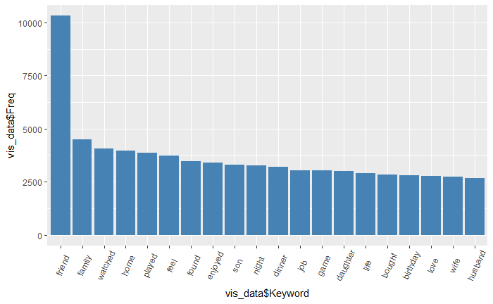

```r
vis_data <- head(sorted_data, n =20)
g <- ggplot(vis_data,aes(fill=vis_data$Keyword)) + geom_bar(aes(x=vis_data$Keyword,y=vis_data$Freq),stat='identity',fill="steelblue")+theme(axis.text.x = element_text(angle=65, vjust=0.6)) +scale_x_discrete(limits= vis_data$Keyword) + guides(fill=FALSE)
g
```

The words are mostly associated with ‘friends’:

```r
hm_data_associate <- hm_data[hm_data$count > 2,]
set.seed(223)
dtm <- DocumentTermMatrix(VCorpus(VectorSource(sample(hm_data_associate$text,200))))
as.matrix(dtm)
```

```r
findAssocs(dtm, terms = "friend", corlimit = 0.2)
```

```
$`friend`
         party       birthday     artificial       attended         awhile babycelebrated       beachits          birth
          0.31           0.26           0.21           0.21           0.21           0.21           0.21           0.21
           bit         boston         cinema      connected        contact          drink      fantastic           golf
          0.21           0.21           0.21           0.21           0.21           0.21           0.21           0.21
          hole          hours         letter           lost       marriage      memorable           park          phone
          0.21           0.21           0.21           0.21           0.21           0.21           0.21           0.21
        pickup    reconnected           ride            sky           snow          sunny          theme         tuxedo
          0.21           0.21           0.21           0.21           0.21           0.21           0.21           0.21
```

### Step13: Topic 1 - What are the different words mentioned by different Countries, USA vs IND? Does it relate to their culture background?

#### the United States and India, two countries, have much more data points than other countries.

```r
count(hm_data$country)[count(hm_data$country)$freq>500,]
```

|  | x | freq |
| --- | --- | --- |
| 15 | CAN | 531 |
| 40 | IND | 16615 |
| 94 | USA | 73377 |
| 95 | VEN | 546 |

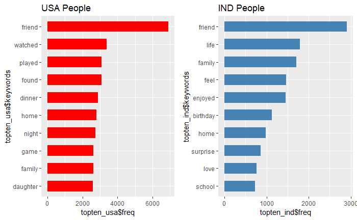

```r
library(gridExtra)
usa_people <- hm_data[which(hm_data$country=="USA"),]
usa_people_word <- usa_people$text %>% str_trim() %>% lapply(strsplit," ") %>% unlist() %>% table() %>% as.data.frame() %>% dplyr::arrange(desc(Freq))
ind_people <- hm_data[which(hm_data$country=="IND"),]
ind_people_word <- ind_people$text %>% str_trim() %>% lapply(strsplit," ") %>% unlist() %>% table() %>% as.data.frame() %>% dplyr::arrange(desc(Freq))
topten_usa<-  usa_people_word[1:10,]
names(topten_usa) <- c("keywords","freq")
g_usa<-ggplot(topten_usa) + geom_bar(aes(x=topten_usa$keywords,y=topten_usa$freq),position="dodge",stat = "identity",width=0.6,fill="red")+scale_x_discrete(limits= rev(topten_usa$keywords))+ guides(fill=F)+ggtitle("USA People")+coord_flip()
topten_ind<- ind_people_word[1:10,]
names(topten_ind) <- c("keywords","freq")
g_ind<-ggplot(topten_ind) + geom_bar(aes(x=topten_ind$keywords,y=topten_ind$freq),position="dodge",stat = "identity",width=0.6,fill="steelblue")+scale_x_discrete(limits= rev(topten_ind$keywords))+ guides(fill=F)+ggtitle("IND People")+coord_flip()
#g_usa,g_ind
grid.arrange(g_usa,g_ind,ncol=2,nrow=1)
```

```r
#cowplot::plot_grid(g_usa,g_ind,labels = "AUTO" )
```

[figure not shown]

```r
library(RColorBrewer)
commonality.cloud(tdm, random.order=FALSE, scale=c(5, .5),colors = brewer.pal(4, "Dark2"), max.words=100)
```

#### The different words used by these two countries - Comparison Cloud

A comparison cloud compares the relative frequency with which a term was used in two or more groups and it plots the difference between the word usage in the documents.

From the comparison cloud, we can see that words like ‘life’ and ‘family’ were more front-and-center in India than in USA. We also see words like ‘temple’ and ‘purchased’, which didn’t exist (at least by that name) in USA, pop up in India’s word cloud, which means it has been used more by India workers.

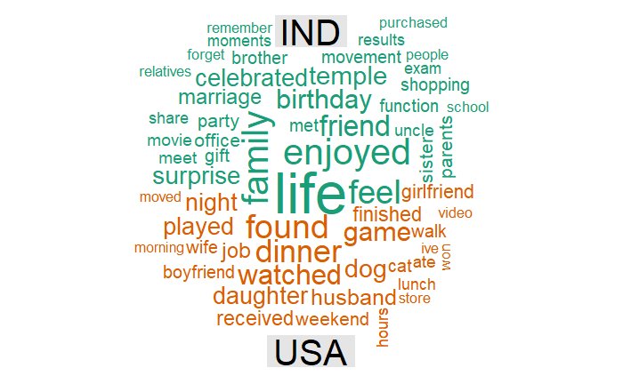

```r
hm_data_country<- hm_data[hm_data$country=='USA'|hm_data$country=='IND',]
bag_of_words2 <-  hm_data_country %>%
  unnest_tokens(word, text)
word_count2 <- bag_of_words2 %>%group_by(country)%>%
  dplyr::count(word, sort = TRUE)
tdm2 <- cast(word_count2,word~country,value = 'n')
tdm2[is.na(tdm2)] <- 0
rownames(tdm2) <- tdm2$word
tdm2$word <- NULL
par(mfrow=c(1,1))
comparison.cloud(tdm2, random.order=FALSE,
                 title.size=2.5, max.words=60)
```

### Step 14: Topic 2 - What are the different words mentioned by different Age groups (Young Adults, Middle Age and Senior) and Gender? And what are the reasons they mentioned some words than other words?

#### Create Age Groups

```r
hm_data$age <- as.numeric(hm_data$age)
hm_data <- hm_data[!is.na(hm_data$age),]
hm_data <- hm_data[hm_data$age<100,] ## Clean the outliers
hm_data <- hm_data[hm_data$age>10,]  ## Clean the outliers
summary(hm_data$age)
```

```
   Min. 1st Qu.  Median    Mean 3rd Qu.    Max.
  17.00   25.00   30.00   31.86   35.00   95.00
```

```r
hm_data$age_group <- ifelse(hm_data$age <= 25,"Young",ifelse(hm_data$age <= 40,"Middle","Senior"))
```

#### Check the distribution of age by gender

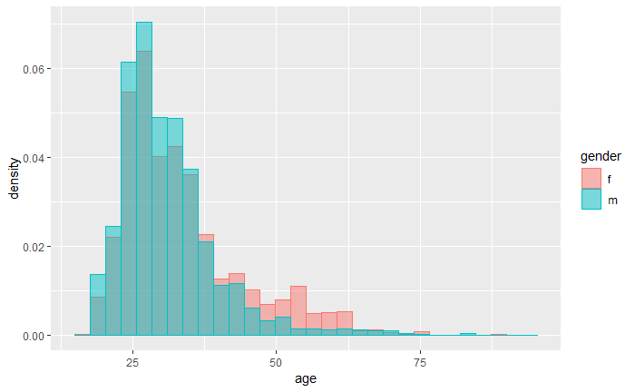

```r
#ggplot(hm_data, aes(x=age)) + geom_histogram()
ggplot(hm_data, aes(x=age, color=gender,fill = gender)) +
  geom_histogram(aes(y=..density..), position="identity", alpha=0.5)
```

#### Check the gender ratio for each age group we created

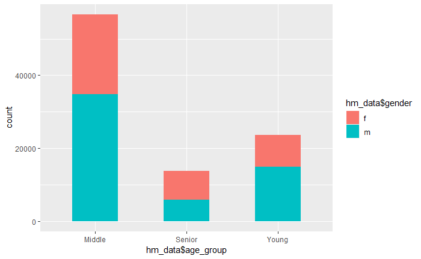

```r
con_data<- hm_data[,c(13)] %>% dplyr::group_by(age_group) %>% count()
con_data <- na.omit(con_data)
#ggplot(con_data,aes(fill=con_data$age_group)) + geom_bar(aes(x= con_data$age_group,y=con_data$freq),stat = 'identity')
g <- ggplot(hm_data,aes(x=hm_data$age_group)) + geom_bar(aes(y = ..count..,fill = hm_data$gender),width = 0.5)
g
```

#### The different words used by these three age groups - Comparison Cloud

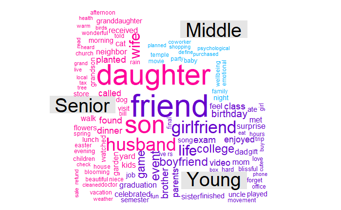

```r
bag_of_words <-  hm_data %>%
  unnest_tokens(word, text)
word_count3 <- bag_of_words %>%group_by(age_group)%>%
  dplyr::count(word, sort = TRUE)
tdm3 <- cast(word_count3,word~age_group,value = 'n')
tdm3[is.na(tdm3)] <- 0
rownames(tdm3) <- tdm3$word
tdm3$word <- NULL
par(mfrow=c(1,1))
comparison.cloud(tdm3, random.order=FALSE,colors = c("#00B2FF", "#FF0099", "#6600CC"),
                 title.size=2.5, max.words=150)
```

From this comparison cloud, we can see that words like ‘friend’, ‘game’ and words related to school were more front-and-center in young adult group than in other two groups. We also see words are smaller in the Middle Age Group, which means this age group shares lots of same words with both two other groups. Words like ‘daughter’ and ‘flowers’ have been used more by senior workers.

#### The different words used by male and female - Comparison Cloud

[figure not shown]

```r
library(reshape)
bag_of_words <-  hm_data %>%
  unnest_tokens(word, text)
word_count <- bag_of_words %>%group_by(gender)%>%
  dplyr::count(word, sort = TRUE)
tdm <- cast(word_count,word~gender,value = 'n')
tdm[is.na(tdm)] <- 0
rownames(tdm) <- tdm$word
tdm$word <- NULL
par(mfrow=c(1,1))
comparison.cloud(tdm, random.order=FALSE, colors = c("indianred3","lightsteelblue3"),
                 title.size=2.5, max.words=200)
```

The gender difference is easy to see by using comparison cloud.

### Step 15: Topic 3 - What are the effect of marriage and parenthood on different age group (Young Adults, Middle Age and Senior)? And what are the reasons they mentioned some words than other words?

#### Age & Marital

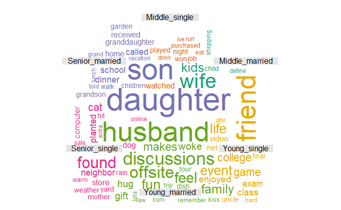

```r
hm_data$combined <- apply( hm_data[ ,c('age_group','marital') ] , 1 , paste , collapse = "_" )
bag_of_words3 <-  hm_data %>%
  unnest_tokens(word, text)
word_count3 <- bag_of_words3 %>%group_by(combined)%>%
  dplyr::count(word, sort = TRUE)
tdm3 <- cast(word_count3,word~combined,value = 'n')
tdm3[is.na(tdm3)] <- 0
rownames(tdm3) <- tdm3$word
tdm3$word <- NULL
par(mfrow=c(1,1))
comparison.cloud(tdm3, random.order=FALSE,
                 title.size=1, max.words=150)
```

```r
NA
```

#### Age & Parenthood

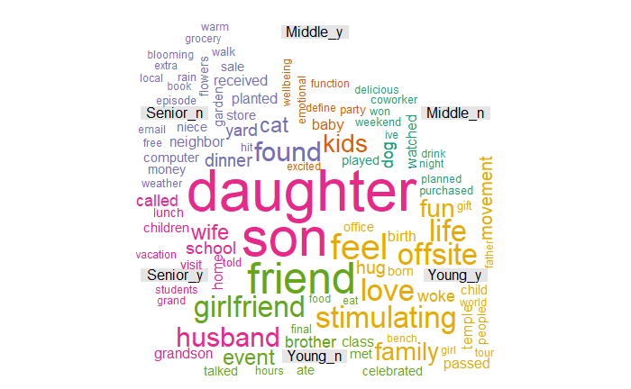

```r
hm_data$combined2 <- apply( hm_data[ ,c('age_group','parenthood') ] , 1 , paste , collapse = "_" )
bag_of_words4 <-  hm_data %>%
  unnest_tokens(word, text)
word_count4 <- bag_of_words4 %>%group_by(combined2)%>%
  dplyr::count(word, sort = TRUE)
tdm4 <- cast(word_count4,word~combined2,value = 'n')
tdm4[is.na(tdm4)] <- 0
rownames(tdm4) <- tdm4$word
tdm4$word <- NULL
par(mfrow=c(1,1))
comparison.cloud(tdm4, random.order=FALSE,
                 title.size=1, max.words=150)
```

```r
NA
```

People engaged in marriage are kind of similar to the conclusion in the marriage. Young adult people who have children would pay more attention to their family but also have energy and time to have fun while while people are not having children are mostly saying things with ‘friend’ and school life; middle age people who have children would put more attention to their kids and their health while middle ages without any children are enjoying lots of leisure time and achievement at work. Sensior people who have children and grandchildren would put lots of their minds onto those family member and would still mention their husband, while Seniors without children would explore lots of different fields in their life.